# Homework- Week 5

Author

Ayrianna Hedgecock

## Problem 1

```r
library(flowCore)
library(flowWorkspace)
library(ggcyto)
library(ggplot2)
library(CytoML)
library(dplyr)
```

```r
# DataFolder <- file.path("course" , "05_GatingSets" , "homeworks", "A-hedgecock-FlowCore", "data") # for actual code

 DataFolder <- file.path("data") # Quarto Rendering
fcs_files <- list.files(DataFolder, pattern = ".fcs", full.names = TRUE)
FlowJoWspFiles <- list.files(DataFolder, pattern = ".wsp", full.names = TRUE)
OpenedWorkspace <- FlowJoWspFiles[stringr::str_detect(FlowJoWspFiles, "Opened")]
OpenedWorkspace
```

```
[1] "data/FlowJoWSP_OpenedCopy.wsp"
```

```r
ws <- open_flowjo_xml(file = OpenedWorkspace)
ws
```

```
File location:  data/FlowJoWSP_OpenedCopy.wsp

Groups in Workspace
         Name Num.Samples
1 All Samples           6
```

```r
fj_gs <- flowjo_to_gatingset(
    ws = ws,
    name = 1,
    path = DataFolder,
    additional.keys = "GROUPNAME"
)
```

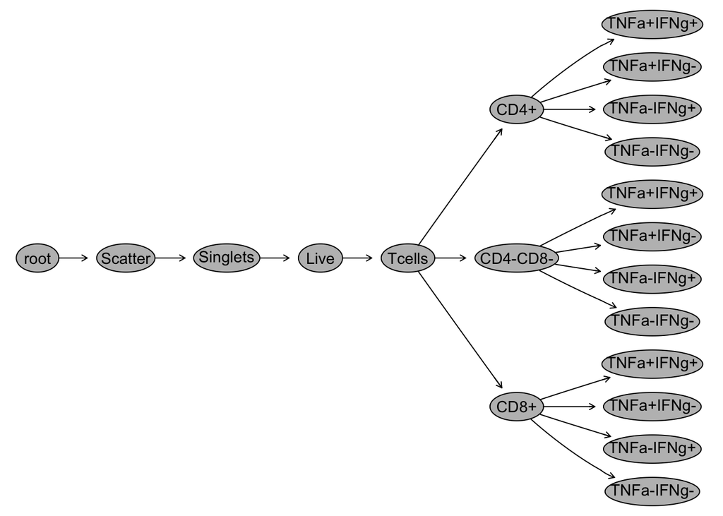

```r
plot(fj_gs)
```

```r
gateList <- gs_get_pop_paths(fj_gs, path = "auto")
counts <- gs_pop_get_count_fast(fj_gs)
```

```r
PercentParent <- mutate(
    counts,
    Percent_Parent =
        round(Count / ParentCount, digits = 2)
)
```

```r
FinishedDataset <- paste0("PercentParentDataset", ".csv")
StorageLocation <- file.path(DataFolder, FinishedDataset)

write.csv(PercentParent, StorageLocation, row.names = FALSE)
```

## Problem 2

```r
GatingSetCytoML <- flowjo_to_gatingset(
    ws,
    name = 1,
    path = DataFolder
)
```

```
Error:
! Multiple FCS files match sample 00_Ctrl.fcs by filename, event count, and keywords.
Candidates are:
/Users/ayrianna/Documents/CytometryInR/course/05_GatingSets/homeworks/A-hedgecock-FlowCore/data/2025_07_26_AB_02_INF052_00_Ctrl.fcs
/Users/ayrianna/Documents/CytometryInR/course/05_GatingSets/homeworks/A-hedgecock-FlowCore/data/2025_07_26_AB_02_INF100_00_Ctrl.fcs
/Users/ayrianna/Documents/CytometryInR/course/05_GatingSets/homeworks/A-hedgecock-FlowCore/data/2025_07_26_AB_02_INF179_00_Ctrl.fcs
Please move incorrect files out of this directory or its subdirectories.
```

**WarningInital Error**

Error: ! Multiple FCS files match sample 00_Ctrl.fcs by filename, event count, and keywords. Candidates are: /Users/ayrianna/Documents/Week5/A-hedgecock-FlowCore/data/2025_07_26_AB_02_INF052_00_Ctrl.fcs /Users/ayrianna/Documents/Week5/A-hedgecock-FlowCore/data/2025_07_26_AB_02_INF100_00_Ctrl.fcs /Users/ayrianna/Documents/Week5/A-hedgecock-FlowCore/data/2025_07_26_AB_02_INF179_00_Ctrl.fcs Please move incorrect files out of this directory or its subdirectories.

**WarningNew Error**

Only these files in folder: “A-hedgecock-FlowCore/data/2025_07_26_AB_02_INF179_00_Ctrl.fcs” “A-hedgecock-FlowCore/data/2025_07_26_AB_02_INF179_00_SEB.fcs”

Error: ! Duplicated GUIDs detected within group: 00_Ctrl.fcs_10000 Consider adding additional keywords to the GUID with argument “additional.keys”or setting argument “additional.sampleID = TRUE” to disambiguate samples further.

## Problem 3

Let’s try FlowSet…

```r
fs <- read.flowSet(
    files = fcs_files,
    transformation = FALSE,
    truncate_max_range = FALSE
)
fs
```

```
A flowSet with 6 experiments.

column names(43): Time SSC-W ... APC-Fire 810-A AF-A
```

```r
gs <- GatingSet(fs)

gs
```

```
A GatingSet with 6 samples
```

This is just the fcs files so no gates should be present:

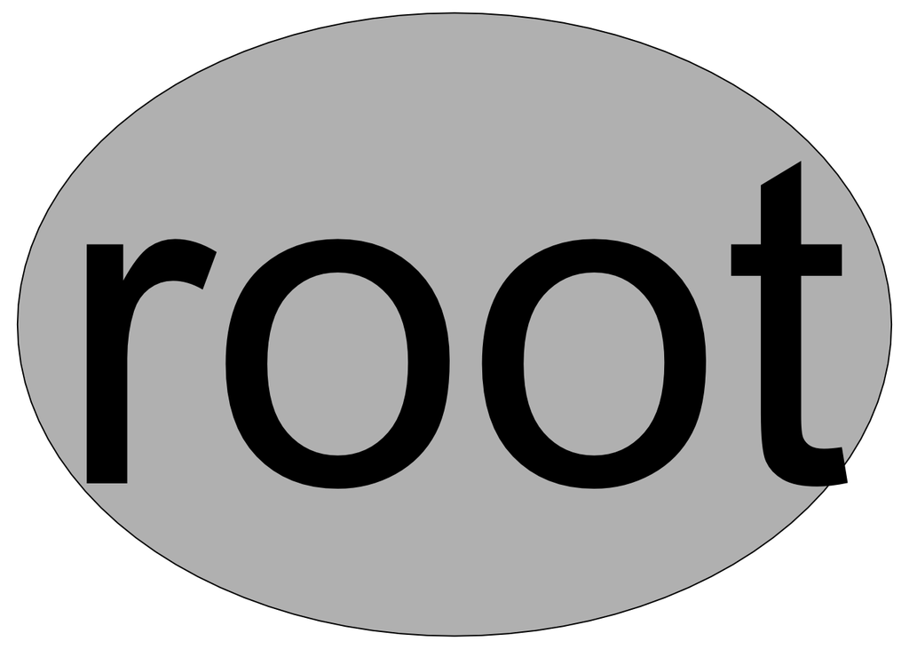

```
Error in `text.default()`:
! no coordinates were supplied
```

```r
plot(gs)
```

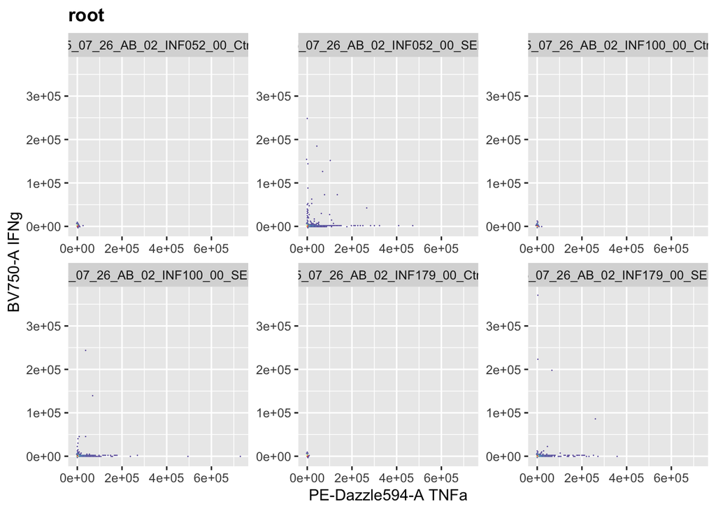

```r
ggcyto(
    gs,
    subset = "root",
    aes(
        x = "TNFa",
        y = "IFNg"
    )
) +
    geom_hex(bins = 128)
```

No data is showing?

Lets try just one file:

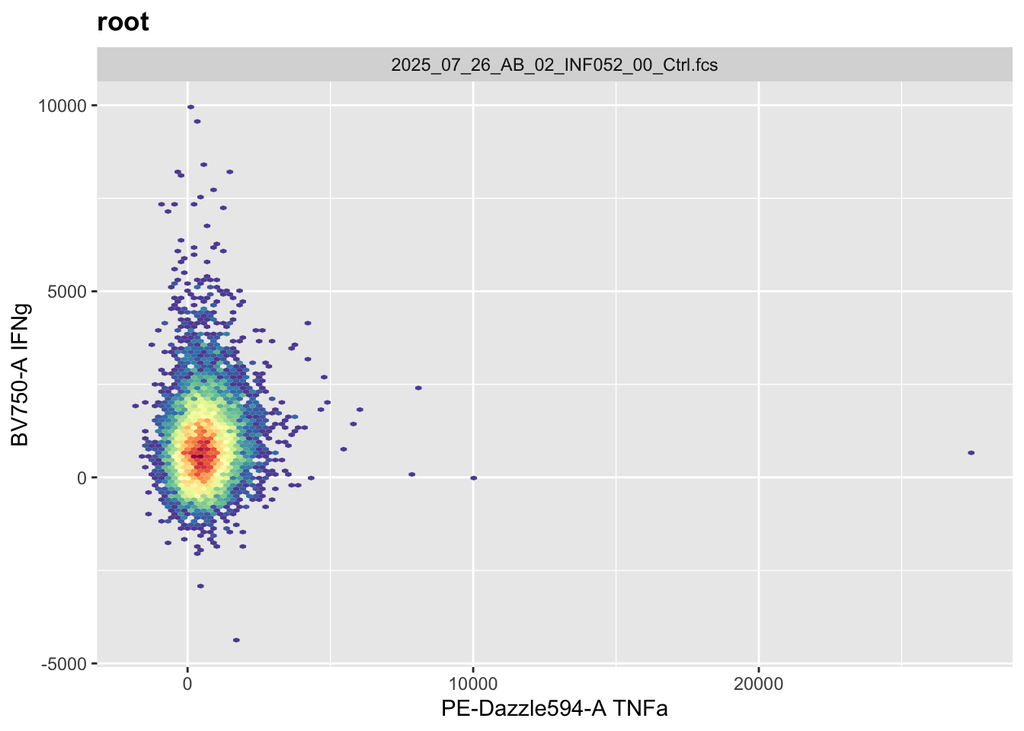

```r
ggcyto(
    gs[1],
    subset = "root",
    aes(
        x = "TNFa",
        y = "IFNg"
    )
) +
    geom_hex(bins = 128)
```

Okay I see data here…

2 files?

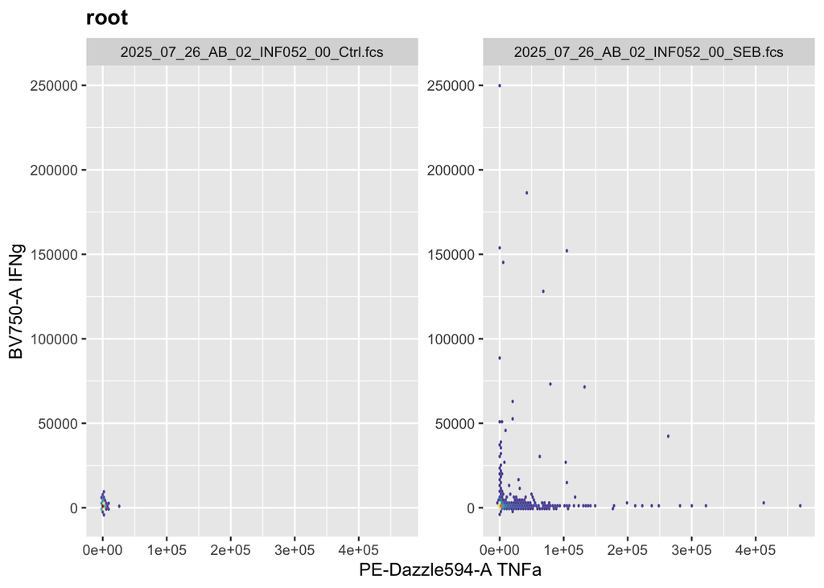

```r
ggcyto(
    gs[c(1:2)],
    subset = "root",
    aes(
        x = "TNFa",
        y = "IFNg"
    )
) +
    geom_hex(bins = 128)
```

Aha, actually data ia shown the whole time but very hard to see! The Scale is weird with the Ctrl vs SEB conditions…play around with the bins?

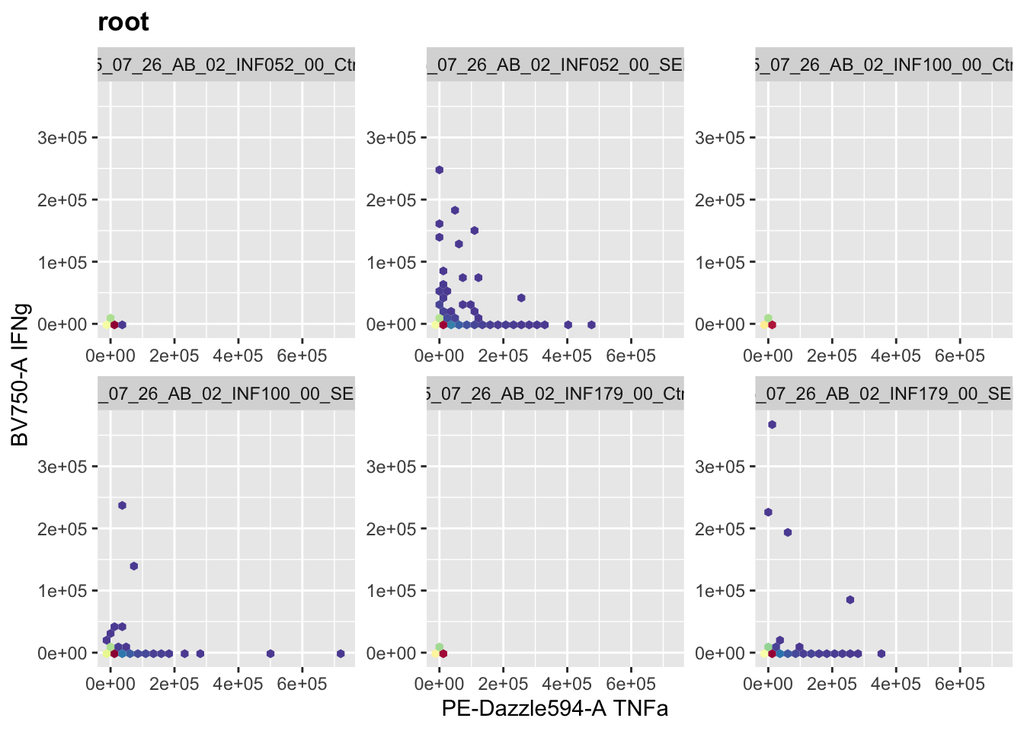

```r
ggcyto(
    gs,
    subset = "root",
    aes(
        x = "TNFa",
        y = "IFNg"
    )
) +
    geom_hex(bins = 30)
```

Let’s try on gated data:

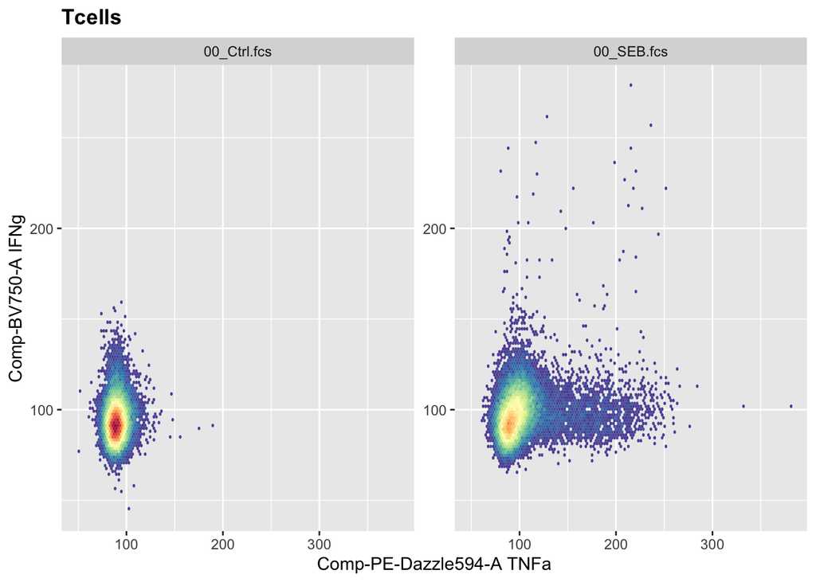

```r
ggcyto(
    fj_gs,
    subset = "Tcells",
    aes(
        x = "TNFa",
        y = "IFNg"
    )
) + geom_hex(bins = 128)
```

Shows overlaid groups? how to sepearate by sample? I.e. sample = row, conditions = columns?

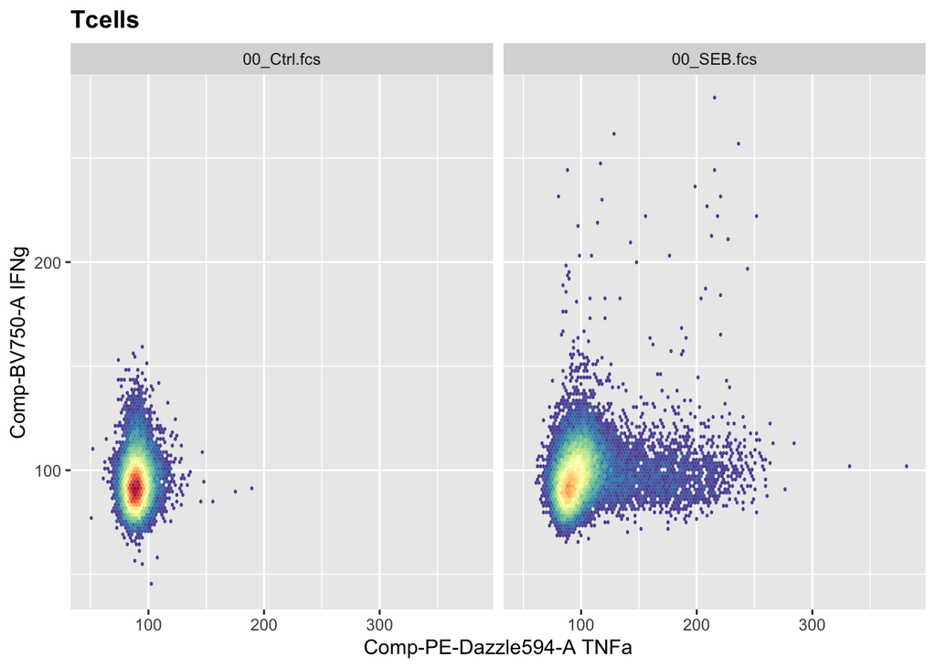

```r
ggcyto(
    fj_gs,
    subset = "Tcells",
    aes(
        x = "TNFa",
        y = "IFNg"
    )
) + geom_hex(bins = 128) +
    facet_grid(~name)
```

Not sure where to go from here… will prob learn more next week…